# Proyecto Asignatura Python - Master UPV

## Autores

- Ignacio Galiano Lopez
- Juanfran Tomás Planells

```python
import pandas as pd
import numpy as np
import matplotlib.pyplot as plt
import seaborn as sns
```

# Reto 1: Relación entre los datos de entrada

```python
df_atletas = pd.read_csv("data/atletas.csv")    # Cambia por el nombre real
df_medallas = pd.read_csv("data/medallas.csv")  # Idem

print("Atletas")
print(df_atletas.head())
print("\nMedallas")
print(df_medallas.head())
```

```
Atletas
   ID                      Name Sex   Age  Height  Weight            Team  NOC
0   1                 A Dijiang   M  24.0   180.0    80.0           China  CHN
1   2                  A Lamusi   M  23.0   170.0    60.0           China  CHN
2   3       Gunnar Nielsen Aaby   M  24.0     NaN     NaN         Denmark  DEN
3   4      Edgar Lindenau Aabye   M  34.0     NaN     NaN  Denmark/Sweden  DEN
4   5  Christine Jacoba Aaftink   F  21.0   185.0    82.0     Netherlands  NED

Medallas
   ID        Games  Year  Season       City          Sport  \
0   1  1992 Summer  1992  Summer  Barcelona     Basketball
1   2  2012 Summer  2012  Summer     London           Judo
2   3  1920 Summer  1920  Summer  Antwerpen       Football
3   4  1900 Summer  1900  Summer      Paris     Tug-Of-War
4   5  1988 Winter  1988  Winter    Calgary  Speed Skating

                              Event Medal
0       Basketball Men's Basketball   NaN
1      Judo Men's Extra-Lightweight   NaN
2           Football Men's Football   NaN
3       Tug-Of-War Men's Tug-Of-War  Gold
4  Speed Skating Women's 500 metres   NaN
```

### Explicación de que aporta cada tabla y cómo se relacionan

La primera tabla (atletas.csv) recoge información personal y básica de cada deportista: un ID único, nombre, sexo, edad, altura, peso, país/equipo y el NOC (comité olímpico nacional).  
La segunda tabla (medallas.csv) describe cada participación olímpica: enlaza el mismo ID de atleta con la edición de los Juegos (año, ciudad, verano/invierno), el deporte, el evento concreto y el tipo de medalla, si la obtuvo.  
Ambas se relacionan a través de la columna ID: gracias a ella podemos unir los datos personales del atleta con sus resultados deportivos en cada edición de los Juegos.

### Muestra un listado de ejemplo (5–10 filas) con: nombre del atleta, país, tipo de juegos, años en los que participó y medallas obtenidas en cada año

```python
df_JJOO = pd.merge(df_atletas, df_medallas, on='ID', how='inner')

# Limpiar datos: filtrar solo filas donde se obtuvo medalla (Medal no es NaN)
df_JJOO_medallas = df_JJOO[df_JJOO['Medal'].notna()]

resumen = (
    df_JJOO_medallas
    .groupby(['Name', 'Team', 'Season', 'Year'])
    .agg(
        Medallas_Obtenidas = ('Medal', 'count')  # Cuenta el número de medallas por grupo
    )
    .reset_index()
)
print(resumen.head(10))
```

```
                    Name                                            Team  \
0              A. Albert  Union des Socits Franais de Sports Athletiques
1              A. Dubois                                       Gitana-21
2  A. Joshua "Josh" West                                   Great Britain
3               A. Lawry                                        Cornwall
4            A. M. Woods          St. Louis Amateur Athletic Association
5            A. R. Upton           Brussels Swimming and Water Polo Club
6           A. Willcocks                                        Cornwall
7             Aage Birch                                           Snude
8      Aage Ernst Larsen                                         Denmark
9       Aage Hy Pedersen                                         Denmark

   Season  Year  Medallas_Obtenidas
0  Summer  1900                   1
1  Summer  1900                   2
2  Summer  2008                   1
3  Summer  1908                   1
4  Summer  1904                   1
5  Summer  1900                   1
6  Summer  1908                   1
7  Summer  1968                   1
8  Summer  1948                   1
9  Summer  1928                   1
```

### Indica 3 preguntas que no se podrían responder usando solo una de las tablas

1. Cantidad de medallas por país: ¿Qué país ha ganado más medallas en total?
2. Edad promedio de los medallistas: ¿Cuál es la edad promedio de los atletas que han ganado medallas por país?
3. Participación por deporte: ¿Cuántos atletas de cada país han participado en deportes específicos habiendo ganado medallas?

### Haz un gráfico de barras apiladas con el nº de participaciones por país para los 10 países con más participaciones, separando Verano/Invierno. Justifica por qué barras apiladas es una buena elección (o propón otro tipo de gráfica y justifícala)

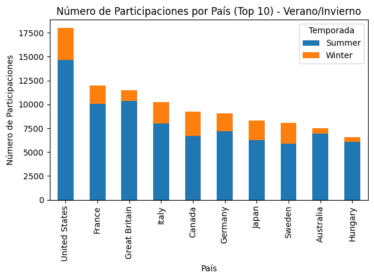

```python
# Número de participaciones por país para los 10 países con más participaciones, separando Verano/Invierno
participaciones = (
    df_JJOO
    .groupby(['Team', 'Season'])
    .size()
    .reset_index(name='Num_Participaciones')
)
top10_paises = (
    participaciones
    .groupby('Team')['Num_Participaciones']
    .sum()
    .nlargest(10)
    .index
)
participaciones_top10 = participaciones[participaciones['Team'].isin(top10_paises)]
# Gráfico de barras apiladas ordenadas de mayor a menor
pivot_participaciones = participaciones_top10.pivot(index='Team', columns='Season', values='Num_Participaciones').fillna(0)
pivot_participaciones = pivot_participaciones.loc[pivot_participaciones.sum(axis=1).sort_values(ascending=False).index]
pivot_participaciones.plot(kind='bar', stacked=True)
plt.title('Número de Participaciones por País (Top 10) - Verano/Invierno')
plt.xlabel('País')
plt.ylabel('Número de Participaciones')
plt.legend(title='Temporada')
plt.tight_layout()
plt.show()
```

## RETO 1: Relación entre los datos de entrada (tablas)

### Implementa la función resumen_participacion(id_atleta, df_medallas) que resuma los años de participación de un atleta concreto en intervalos consecutivos

```python
def resumen_participacion(id_atleta, df_medallas):
    df_atleta = df_medallas[df_medallas['ID'] == id_atleta]
    year_participation = df_atleta['Year'].unique().tolist()
    year_participation.sort()
    print(year_participation)
    if not year_participation:
        return "El atleta no ha participado en ningún año."

    intervalos = []
    inicio = year_participation[0]
    year_aux = inicio
    for year in year_participation[1:]:
        if year - year_aux > 4:
            intervalos.append("-".join([str(inicio), str(year_aux)]))
            inicio = year
            year_aux = year
        else:
            year_aux = year
    intervalos.append("-".join([str(inicio), str(year_aux)]))
    return {"participaciones": len(year_participation), "intervalos": intervalos}

print(resumen_participacion(79855, df_medallas))
```

```
[1972, 1976, 1984, 1988, 1992, 1996, 2000, 2004, 2008, 2012]
{'participaciones': 10, 'intervalos': ['1972-1976', '1984-2012']}
```

# RETO 2

### Obtén la edad media de los atletas diferenciando entre juegos de Verano e Invierno (muestra ambas y compáralas en 3–5 líneas)

```python
df_JJOO['Age'] = pd.to_numeric(df_JJOO['Age'], errors='coerce')

df_edades = df_JJOO.dropna(subset=['Age'])

tabla_edades = (
    df_edades
    .groupby(['Season', 'Sex'])['Age']
    .agg(['mean', 'count'])
    .reset_index()
)

tabla_pivot = tabla_edades.pivot(index='Sex', columns='Season', values='mean')
print("\nEdad media (tabla pivot):")
print(tabla_pivot)
```

```
Edad media (tabla pivot):
Season     Summer     Winter
Sex
F       21.899688  21.694002
M       24.671116  23.315536
```

Los datos muestran que la edad media de los atletas en los Juegos de Invierno es inferior a la de los Juegos de Verano. Aunque la diferencia no es muy grande, sí es consistente: los participantes en competiciones invernales tienden a ser ligeramente más jóvenes. Este resultado indica simplemente un patrón general en la distribución de edades entre ambas temporadas, sin que pueda atribuirse a una causa concreta con la información disponible actualmente.

### Muestra un histograma de edades de los 5 países con más atletas participantes (un FacetGrid de histogramas por país)

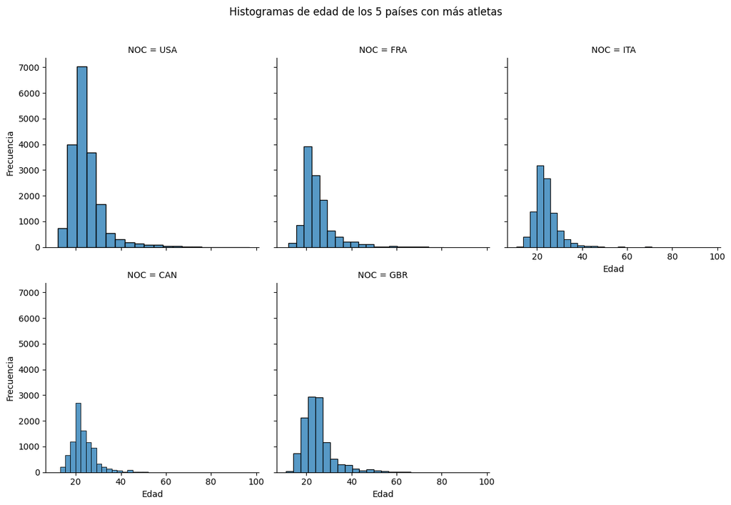

```python
# Top 5 países con más atletas (atletas únicos)
top5_paises = (
    df_JJOO.dropna(subset=['Age'])           # sólo registros con edad
           .groupby('NOC')['ID']
           .nunique()                        # numero de atletas distintos
           .nlargest(5)
           .index
)

# Datos solo de esos países y con edad válida
df_top5 = df_JJOO[df_JJOO['NOC'].isin(top5_paises) & df_JJOO['Age'].notna()]

# FacetGrid de histogramas de edad por país
g = sns.FacetGrid(df_top5, col='NOC', col_wrap=3, height=4, sharex=True, sharey=True)
g.map_dataframe(sns.histplot, x='Age', bins=20)

g.set_axis_labels("Edad", "Frecuencia")
g.figure.suptitle("Histogramas de edad de los 5 países con más atletas", y=1.02)
plt.tight_layout()
plt.show()
```

### Muestra la 8 distribución porcentual segregando por Hombre/Mujer y Verano/Invierno, en una gráfica adecuada (en porcentajes, no conteos). Justifica el tipo de gráfica por el que has optado.

```
   Season Sex  Conteo  Porcentaje
0  Summer   F   59443   26.709713
1  Summer   M  163109   73.290287
2  Winter   F   15079   31.049749
3  Winter   M   33485   68.950251
```

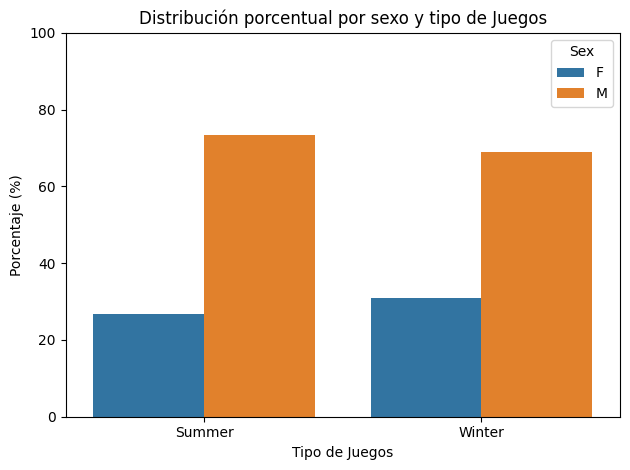

```python
# Nos quedamos solo con filas que tienen Season y Sex
df_sexo = df_JJOO.dropna(subset=['Season', 'Sex'])

# Conteos por temporada y sexo
tabla_sexo = (
    df_sexo
    .groupby(['Season', 'Sex'])['ID']
    .count()
    .reset_index(name='Conteo')
)

# Pasamos a porcentajes dentro de cada temporada (Summer / Winter)
tabla_sexo['Porcentaje'] = (
    tabla_sexo['Conteo'] /
    tabla_sexo.groupby('Season')['Conteo'].transform('sum')
) * 100

print(tabla_sexo)

# Gráfica: barras agrupadas con porcentajes
sns.barplot(
    data=tabla_sexo,
    x='Season',
    y='Porcentaje',
    hue='Sex'
)

plt.title('Distribución porcentual por sexo y tipo de Juegos')
plt.xlabel('Tipo de Juegos')
plt.ylabel('Porcentaje (%)')
plt.ylim(0, 100)
plt.tight_layout()
plt.show()
```

Se ha utilizado un gráfico de barras agrupadas con el porcentaje de participaciones en el eje vertical, diferenciando el tipo de Juegos (Verano/Invierno) en el eje horizontal y el sexo mediante el color. Este tipo de gráfica permite comparar de forma muy directa la proporción de hombres y mujeres dentro de cada edición, manteniendo siempre la referencia común del 100% por temporada. Frente a mostrar conteos absolutos, el uso de porcentajes facilita la comparación relativa entre Verano e Invierno independientemente del número total de participaciones en cada uno.

### Calcula la altura y peso medio de las mujeres en los 5 deportes en los que hay más mujeres que hombres, y muestra una visualización que permita comparar esa distribución (p. ej., boxplots por deporte). Añade al menos 2 comentarios sobre qué muestran los resultados obtenidos

```
Deportes con más mujeres que hombres (Top 5):
['Synchronized Swimming', 'Figure Skating', 'Rhythmic Gymnastics', 'Softball', 'Curling']

Altura y peso medios de mujeres en los 5 deportes seleccionados:
                       Height  Weight
Sport
Curling                167.80   62.89
Figure Skating         160.55   49.86
Rhythmic Gymnastics    167.80   48.76
Softball               169.43   67.47
Synchronized Swimming  168.49   55.86
```

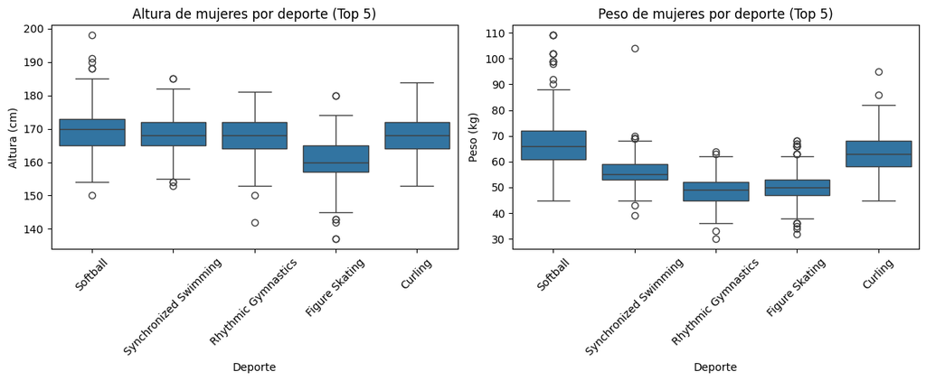

```python
# Aseguramos que Height y Weight son numéricos
df_JJOO['Height'] = pd.to_numeric(df_JJOO['Height'], errors='coerce')
df_JJOO['Weight'] = pd.to_numeric(df_JJOO['Weight'], errors='coerce')

# Nos quedamos solo con filas que tienen sexo, deporte, altura y peso
df_hw = df_JJOO.dropna(subset=['Sex', 'Sport', 'Height', 'Weight'])

# Conteos por deporte y sexo
conteos = (
    df_hw
    .groupby(['Sport', 'Sex'])
    .size()
    .reset_index(name='Conteo')
)

# Pasamos a tabla con columnas F y M
tabla_sexo_deporte = conteos.pivot(index='Sport', columns='Sex', values='Conteo').fillna(0)

# Nos quedamos solo con deportes con más mujeres que hombres
deportes_mas_mujeres = tabla_sexo_deporte[
    tabla_sexo_deporte.get('F', 0) > tabla_sexo_deporte.get('M', 0)
].copy()

# Ordenamos por numero de mujeres y cogemos los 5 con más mujeres
deportes_top5 = (
    deportes_mas_mujeres
    .sort_values(by='F', ascending=False)
    .head(5)
    .index
)

print("Deportes con más mujeres que hombres (Top 5):")
print(list(deportes_top5))

# Filtramos solo Mujeres (F) en esos 5 deportes
df_mujeres_top5 = df_hw[(df_hw['Sex'] == 'F') & (df_hw['Sport'].isin(deportes_top5))]

# Calculamos altura y peso MEDIOS de las mujeres en esos deportes (por si lo quieres ver en tabla)
medias_mujeres = (
    df_mujeres_top5
    .groupby('Sport')[['Height', 'Weight']]
    .mean()
    .round(2)
)

print("\nAltura y peso medios de mujeres en los 5 deportes seleccionados:")
print(medias_mujeres)

# Visualización: boxplots por deporte para Height y Weight

plt.figure(figsize=(12, 5))

plt.subplot(1, 2, 1)
sns.boxplot(data=df_mujeres_top5, x='Sport', y='Height')
plt.title('Altura de mujeres por deporte (Top 5)')
plt.xlabel('Deporte')
plt.ylabel('Altura (cm)')
plt.xticks(rotation=45)

plt.subplot(1, 2, 2)
sns.boxplot(data=df_mujeres_top5, x='Sport', y='Weight')
plt.title('Peso de mujeres por deporte (Top 5)')
plt.xlabel('Deporte')
plt.ylabel('Peso (kg)')
plt.xticks(rotation=45)

plt.tight_layout()
plt.show()
```

El patrón del peso es coherente con el de la altura: Softball destaca por los pesos más elevados y la mayor dispersión, incluyendo registros por encima de 90–100 kg. Rhythmic Gymnastics agrupa a las deportistas más ligeras, con valores concentrados entre 40 kg y 55 kg. Synchronized Swimming y Figure Skating se sitúan en posiciones intermedias, mostrando distribuciones relativamente homogéneas.

### Implementa la función extremos_atletas(df_atletas) que devuelva un diccionario con los/las atletas “extremos” (más joven, más mayor, de mayor altitud, menor altitud, con menor peso y mayor peso), y que aplique ciertas reglas de desempate (descritas a continuación)

```python
def extremos_atletas(df_atletas):
    """
    Devuelve un diccionario con atletas extremos:
    - mas_joven / mas_mayor (Age)
    - mas_alto / mas_bajo (Height)
    - mas_ligero / mas_pesado (Weight)

    Reglas:
    - Descarta valores no numéricos y no plausibles.
    - Desempate: por nombre (alfabético).
    - Incluye país (NOC) en la salida (propia).
    """

    df = df_atletas.copy()

    # Convertir a numérico (lo no convertible pasa a NaN)
    df['Age'] = pd.to_numeric(df['Age'], errors='coerce')
    df['Height'] = pd.to_numeric(df['Height'], errors='coerce')
    df['Weight'] = pd.to_numeric(df['Weight'], errors='coerce')


    df_valid = df[
        df['Age'].between(10, 80) &
        df['Height'].between(120, 250) &
        df['Weight'].between(30, 200)
    ].dropna(subset=['Age', 'Height', 'Weight'])

    if df_valid.empty:
        return {}

    def seleccionar_extremo(df_in, col, modo, etiqueta_valor):
        # Desempate por nombre (A-Z)
        if modo == 'min':
            df_sorted = df_in.sort_values(by=[col, 'Name'], ascending=[True, True])
        else:
            df_sorted = df_in.sort_values(by=[col, 'Name'], ascending=[False, True])

        fila = df_sorted.iloc[0]
        # Se incluye el pais como complemento informativo
        return {
            "id": int(fila['ID']),
            "nombre": fila['Name'],
            "pais": fila['NOC'],
            etiqueta_valor: float(fila[col])
        }

    return {
        "mas_joven":  seleccionar_extremo(df_valid, 'Age', 'min', 'edad'),
        "mas_mayor":  seleccionar_extremo(df_valid, 'Age', 'max', 'edad'),
        "mas_alto":   seleccionar_extremo(df_valid, 'Height', 'max', 'altura'),
        "mas_bajo":   seleccionar_extremo(df_valid, 'Height', 'min', 'altura'),
        "mas_ligero": seleccionar_extremo(df_valid, 'Weight', 'min', 'peso'),
        "mas_pesado": seleccionar_extremo(df_valid, 'Weight', 'max', 'peso'),
    }
```

```python
res = extremos_atletas(df_atletas)
print(type(res))
print(res.keys())

res = extremos_atletas(df_atletas)
print(res)
```

[output not shown]

# RETO 3: Cantidad de medallas y rendimiento

### Dibuja un mapa de calor de país × deporte (en el que la intensidad sea el número total de medallas)

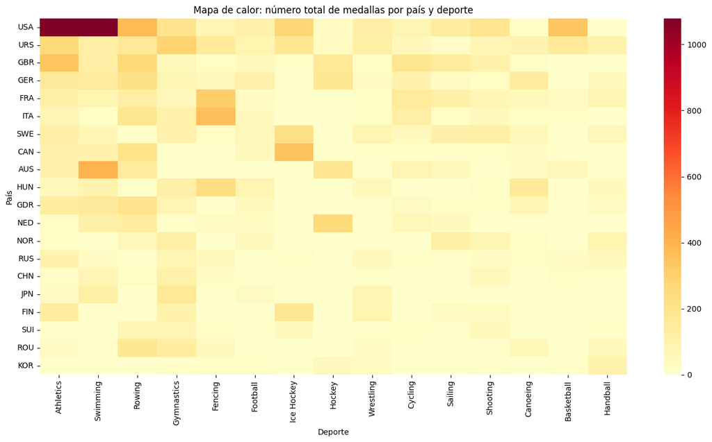

```python
df_med = df_JJOO[df_JJOO['Medal'].isin(['Gold', 'Silver', 'Bronze'])]

# Tabla país x deporte con número total de medallas
tabla_pais_deporte = (
    df_med
    .groupby(['NOC', 'Sport'])
    .size()
    .reset_index(name='Medallas')
)

# Pivot para el heatmap
heatmap_data = tabla_pais_deporte.pivot(
    index='NOC',
    columns='Sport',
    values='Medallas'
).fillna(0)

# Limitar a países/deportes más relevantes asi el heatmap es más legible
top_paises = heatmap_data.sum(axis=1).sort_values(ascending=False).head(20).index
top_deportes = heatmap_data.sum(axis=0).sort_values(ascending=False).head(15).index

heatmap_data = heatmap_data.loc[top_paises, top_deportes]

# Heatmap
plt.figure(figsize=(14, 8))
sns.heatmap(heatmap_data, cmap='YlOrRd')
plt.title('Mapa de calor: número total de medallas por país y deporte')
plt.xlabel('Deporte')
plt.ylabel('País')
plt.tight_layout()
plt.show()
```

### Obtén la clasificación de los 10 países con mayor número total de medallas (de cualquier tipo) y, para cada uno de esos 10 países, el deporte en el que más medallas ha conseguido

```python
# Top 10 países con más medallas
top10_paises_medallas = (
    df_med
    .groupby('NOC')
    .size()
    .nlargest(10)
    .index
)
print("Top 10 países con más medallas:")
print(list(top10_paises_medallas))

dic_paises_medallas = {}
# Deporte con más medallas por cada uno de esos países
for pais in top10_paises_medallas:
    deporte_top = (
        df_med[df_med['NOC'] == pais]
        .groupby('Sport')
        .size()
        .nlargest(1)
    )
    deporte_nombre = deporte_top.index[0]
    num_medallas = deporte_top.iloc[0]
    total_medallas = (
        df_med[df_med['NOC'] == pais]
        .shape[0]
    )
    dic_pais_medallas = {
        "pais": pais,
        "deporte_top": deporte_nombre,
        "num_medallas_deporte_top": int(num_medallas),
        "total_medallas": int(total_medallas)
    }
    dic_paises_medallas[pais] = dic_pais_medallas

print("\nDeporte con más medallas por país (Top 10 países):")
for pais, info in dic_paises_medallas.items():
    print(info)
```

```
Top 10 países con más medallas:
['USA', 'URS', 'GBR', 'GER', 'FRA', 'ITA', 'SWE', 'CAN', 'AUS', 'HUN']

Deporte con más medallas por país (Top 10 países):
{'pais': 'USA', 'deporte_top': 'Athletics', 'num_medallas_deporte_top': 1079, 'total_medallas': 5633}
{'pais': 'URS', 'deporte_top': 'Gymnastics', 'num_medallas_deporte_top': 290, 'total_medallas': 2660}
{'pais': 'GBR', 'deporte_top': 'Athletics', 'num_medallas_deporte_top': 340, 'total_medallas': 2075}
{'pais': 'GER', 'deporte_top': 'Rowing', 'num_medallas_deporte_top': 216, 'total_medallas': 2049}
{'pais': 'FRA', 'deporte_top': 'Fencing', 'num_medallas_deporte_top': 310, 'total_medallas': 1773}
{'pais': 'ITA', 'deporte_top': 'Fencing', 'num_medallas_deporte_top': 359, 'total_medallas': 1627}
{'pais': 'SWE', 'deporte_top': 'Ice Hockey', 'num_medallas_deporte_top': 217, 'total_medallas': 1535}
{'pais': 'CAN', 'deporte_top': 'Ice Hockey', 'num_medallas_deporte_top': 348, 'total_medallas': 1347}
{'pais': 'AUS', 'deporte_top': 'Swimming', 'num_medallas_deporte_top': 399, 'total_medallas': 1314}
{'pais': 'HUN', 'deporte_top': 'Fencing', 'num_medallas_deporte_top': 236, 'total_medallas': 1131}
```

### De los 5 países líderes en medallas, calcula la evolución por décadas de su cantidad de medallas (elige y justifica cómo discretizar las décadas). Muestra una serie temporal por décadas y añade una breve conclusión

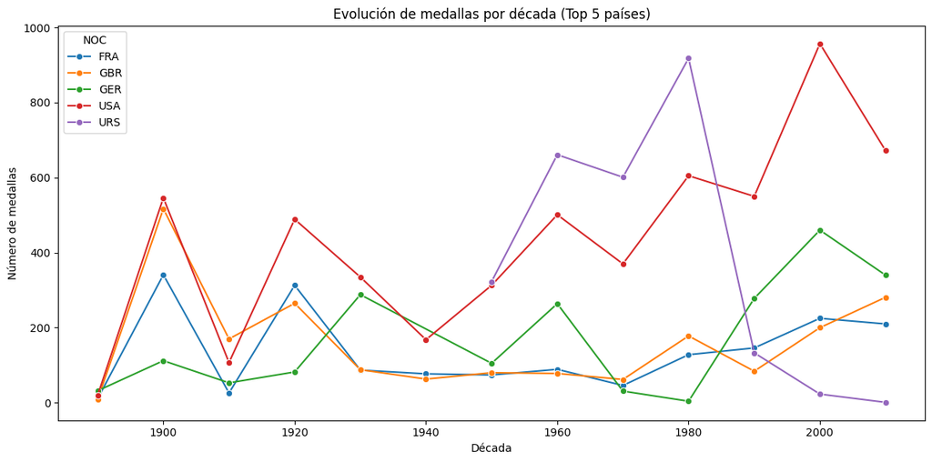

```python
# Top 5 países por número total de medallas
top5_paises = (
    df_med.groupby('NOC')
          .size()
          .sort_values(ascending=False)
          .head(5)
          .index
)

df_top5 = df_med[df_med['NOC'].isin(top5_paises)].copy()

# Década
df_top5['Year'] = pd.to_numeric(df_top5['Year'], errors='coerce')
df_top5 = df_top5.dropna(subset=['Year'])
df_top5['Year'] = df_top5['Year'].astype(int)
df_top5['Decada'] = (df_top5['Year'] // 10) * 10

# Medallas por década y país
medallas_decada = (
    df_top5.groupby(['Decada', 'NOC'])
           .size()
           .reset_index(name='Medallas')
)

# Serie temporal
plt.figure(figsize=(12, 6))
sns.lineplot(data=medallas_decada, x='Decada', y='Medallas', hue='NOC', marker='o')
plt.title('Evolución de medallas por década (Top 5 países)')
plt.xlabel('Década')
plt.ylabel('Número de medallas')
plt.tight_layout()
plt.show()
```

Se agrupan los datos por décadas para suavizar variaciones puntuales de ediciones concretas y observar tendencias generales de largo plazo en la evolución de medallas de los países líderes.

### Elige un deporte y analiza si hay relación entre la altura/peso de los deportistas y probabilidad de medalla en función del país. Compara todos los países para el deporte elegido, muestra una gráfica adecuada e interpreta los resultados (en 5–8 líneas)

```
    NOC  Height_bin  Probabilidad_medalla
0   CAN  (140, 160]              0.096154
1   CAN  (160, 170]              0.105769
2   CAN  (170, 180]              0.093664
3   CAN  (180, 200]              0.078571
4   FRA  (140, 160]              0.081633
5   FRA  (160, 170]              0.048951
6   FRA  (170, 180]              0.103044
7   FRA  (180, 200]              0.071240
8   GBR  (140, 160]              0.043478
9   GBR  (160, 170]              0.166259
10  GBR  (170, 180]              0.168317
11  GBR  (180, 200]              0.147708
12  GER  (140, 160]              0.200000
13  GER  (160, 170]              0.122807
14  GER  (170, 180]              0.157080
15  GER  (180, 200]              0.103604
16  USA  (140, 160]              0.255102
17  USA  (160, 170]              0.307252
18  USA  (170, 180]              0.295051
19  USA  (180, 200]              0.395205
```

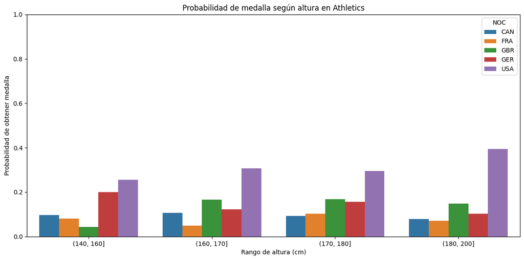

```python
deporte = 'Athletics'

df_dep = df_JJOO[df_JJOO['Sport'] == deporte].copy()

# Medallista sí/no
df_dep['Medallist'] = df_dep['Medal'].isin(['Gold', 'Silver', 'Bronze'])

# Limpiamos altura
df_dep['Height'] = pd.to_numeric(df_dep['Height'], errors='coerce')
df_dep = df_dep.dropna(subset=['Height'])

# Países principales
top_paises = df_dep['NOC'].value_counts().head(5).index
df_dep = df_dep[df_dep['NOC'].isin(top_paises)]

# Rangos de altura (bins)
df_dep['Height_bin'] = pd.cut(
    df_dep['Height'],
    bins=[140, 160, 170, 180, 200]
)

# Probabilidad de medalla por país y rango de altura
prob_medalla = (
    df_dep
    .groupby(['NOC', 'Height_bin'], observed=False)['Medallist']
    .mean()
    .reset_index(name='Probabilidad_medalla')
)

print(prob_medalla)

plt.figure(figsize=(12,6))
sns.barplot(
    data=prob_medalla,
    x='Height_bin',
    y='Probabilidad_medalla',
    hue='NOC'
)
plt.ylabel('Probabilidad de obtener medalla')
plt.xlabel('Rango de altura (cm)')
plt.title(f'Probabilidad de medalla según altura en {deporte}')
plt.ylim(0, 1)
plt.tight_layout()
plt.show()
```

### Implementa la función ranking_paises_medallas(df_medallas, k) que devuelva devuelva el Top-k de países

```python
def ranking_paises_medallas(df_medallas, k):
    df = df_medallas.copy()

    # Medallas reales y Year válido
    df = df[df['Medal'].isin(['Gold', 'Silver', 'Bronze'])]
    df['Year'] = pd.to_numeric(df['Year'], errors='coerce')
    df = df.dropna(subset=['Year'])
    df['Year'] = df['Year'].astype(int)

    # Conteo oro/plata/bronce por país
    tabla = (
        df.groupby(['NOC', 'Medal'])
          .size()
          .unstack(fill_value=0)
          .rename(columns={'Gold': 'oro', 'Silver': 'plata', 'Bronze': 'bronce'})
          .reset_index()
    )

    # Primer año con medalla por país
    primer_ano = (
        df.groupby('NOC')['Year']
          .min()
          .reset_index()
          .rename(columns={'Year': 'primer_año'})
    )

    # Unir, ordenar por reglas y devolver Top-k
    tabla = tabla.merge(primer_ano, on='NOC', how='left')
    tabla = tabla.sort_values(
        by=['oro', 'plata', 'bronce', 'primer_año', 'NOC'],
        ascending=[False, False, False, True, True]
    ).head(k)

    return [
        {"orden": i, "pais": row.NOC, "oro": int(row.oro), "plata": int(row.plata),
         "bronce": int(row.bronce), "primer_año": int(row.primer_año)}
        for i, row in enumerate(tabla.itertuples(index=False), start=1)
    ]
```

# Reto 4: Edad de entrada y longevidad deportiva

## Descripción

En este reto se analiza la edad de entrada y la longevidad deportiva de los atletas olímpicos, con el objetivo de identificar diferencias estructurales entre los distintos deportes. La edad de entrada se define como la edad del atleta en su primera participación olímpica, mientras que la longevidad se mide como el número total de ediciones olímpicas en las que participa. El análisis se realiza agregando la información por deporte, utilizando la media como medida representativa, y diferenciando entre Juegos de Verano e Invierno.

## Tareas del reto

1. Preparar y combinar las tablas de atletas y medallas para identificar la primera participación olímpica de cada atleta.
2. Calcular la edad de entrada y el número de ediciones en las que participa cada atleta.
3. Agregar las métricas de edad de entrada y longevidad a nivel de deporte, utilizando la media como medida representativa y diferenciando entre Juegos de Verano e Invierno.
4. Visualizar la relación entre edad de entrada y longevidad deportiva.
5. Interpretar los resultados y discutir posibles limitaciones del análisis.

## Decisiones importantes en el análisis

- Se utiliza la **media** como medida de agregación debido a la presencia de valores extremos en ambas variables.
- Se analizan **todos los deportes** presentes en el dataset, sin aplicar filtros adicionales.
- La longevidad se mide en ediciones olímpicas y no en años, porque entre unos Juegos y otros siempre pasan varios años, y no todos los atletas pueden competir en todas las ediciones.

## Función de soporte

Para facilitar el análisis, se proporciona la siguiente función que calcula la edad de entrada y la longevidad deportiva de los atletas:

- **Entrada**: DataFrame resultante de la combinación de atletas y medallas.
- **Salida**: DataFrame con una fila por atleta que incluye:
  - edad de entrada
  - número de participaciones olímpicas
- **Descripción**: La función identifica la primera participación olímpica de cada atleta y calcula las métricas asociadas.

[figure not shown]

```python
# Función de soporte
def resumen_carrera_atleta(df_atletas_medallas):
    """
    Devuelve una fila por atleta con:
      - Primer_Año, Primer_Temporada, Primer_Deporte (de la primera participación)
      - Primera_Edad (edad en la primera participación, con imputación si es posible)
      - Numero_de_Participaciones (conteo de ediciones; usa 'Games' si está disponible)
    """
    df_copia = df_atletas_medallas.copy()

    # Definir edades válidas
    mascara_edades_validas = pd.notna(df_copia["Age"]) & (df_copia["Age"] >= 10) & (df_copia["Age"] <= 100)

    # Construir base de atleta desde edades VÁLIDAS:
    #    Ordenar por Año para asegurar que "primero" corresponda al año más temprano.
    df_base = (
        df_copia.loc[mascara_edades_validas]
          .sort_values(["ID", "Year"])
          .groupby("ID", as_index=False)
          .first()[["ID", "Year", "Age"]]
          .rename(columns={"Year": "año_base", "Age": "edad_base"})
    )

    # Adjuntar base a todas las filas
    df_copia = df_copia.merge(df_base, on="ID", how="left")

    # Imputar edades inválidas cuando hay edad base disponible
    mascara_invalida = ~mascara_edades_validas
    se_puede_imputar = mascara_invalida & pd.notna(df_copia["edad_base"]) & pd.notna(df_copia["año_base"])
    df_copia.loc[se_puede_imputar, "Age"] = df_copia.loc[se_puede_imputar, "edad_base"] + (df_copia.loc[se_puede_imputar, "Year"] - df_copia.loc[se_puede_imputar, "año_base"])

    # Determinar fila de primera participación por atleta
    #    Ordenar por Año (y Edad como desempate) para asegurar que "primero" sea correcto
    df_primero = (
        df_copia.sort_values(["ID", "Year", "Age"], na_position="last")
          .groupby("ID", as_index=False)
          .first()
    )

    # Calcular número de ediciones en las que participó
    if "Games" in df_copia.columns and df_copia["Games"].notna().any():
        participaciones = (
            df_copia.groupby("ID")["Games"]
              .nunique()
              .reset_index(name="Numero_de_Participaciones")
        )
    else:
        # alternativa: contar pares únicos (Year, Season) si Games no está disponible
        participaciones = (
            df_copia.dropna(subset=["Year", "Season"])
              .groupby("ID")[["Year", "Season"]]
              .apply(lambda x: x.drop_duplicates().shape[0])
              .reset_index(name="Numero_de_Participaciones")
        )

    # Resultado final: una fila por atleta con contexto de primera participación
    resultado = (
        df_primero[["ID", "Year", "Season", "Sport", "Age"]]
          .rename(columns={
              "Year": "Primer_Año",
              "Season": "Primer_Temporada",
              "Sport": "Primer_Deporte",
              "Age": "Primera_Edad"
          })
          .merge(participaciones, on="ID", how="left")
    )

    return resultado


# Tarea 1: Fusionar datasets
df_atletas_medallas = pd.merge(df_atletas, df_medallas, on="ID", how="inner")

# Tarea 2: Resumen de carrera de atleta
df_atletas_inicio_longevidad = resumen_carrera_atleta(df_atletas_medallas)

# Tarea 3: Agregar por deporte + temporada
# IMPORTANTE: Usar Primer_Deporte / Primer_Temporada (consistente con definición de edad de entrada)
df_resumen_deporte_temporada_mediana = (
    df_atletas_inicio_longevidad
      .dropna(subset=["Primera_Edad", "Numero_de_Participaciones", "Primer_Deporte", "Primer_Temporada"])
      .groupby(["Primer_Deporte", "Primer_Temporada"], as_index=False)
      .agg(
          Mediana_Primera_Edad=("Primera_Edad", "median"),
          Mediana_Longevidad=("Numero_de_Participaciones", "median")
      )
      .rename(columns={"Primer_Deporte": "Deporte", "Primer_Temporada": "Temporada"})
)

df_resumen_deporte_temporada_promedio = (
    df_atletas_inicio_longevidad
      .dropna(subset=["Primera_Edad", "Numero_de_Participaciones", "Primer_Deporte", "Primer_Temporada"])
      .groupby(["Primer_Deporte", "Primer_Temporada"], as_index=False)
      .agg(
          Mediana_Primera_Edad=("Primera_Edad", "mean"),
          Mediana_Longevidad=("Numero_de_Participaciones", "mean")
      )
      .rename(columns={"Primer_Deporte": "Deporte", "Primer_Temporada": "Temporada"})
)


# Tarea 4: Visualización (scatter)
plt.figure(figsize=(12, 8))
sns.scatterplot(
    data=df_resumen_deporte_temporada_promedio,
    x="Mediana_Primera_Edad",
    y="Mediana_Longevidad",
    hue="Temporada",
    s=100
)

plt.title("Edad de entrada vs Longevidad por Deporte (Mediana) — Verano vs Invierno")
plt.xlabel("Mediana edad de entrada (primera participación)")
plt.ylabel("Mediana longevidad (número de ediciones olímpicas)")
plt.legend(title="Temporada")
plt.grid(True)
plt.show()
```

Dado que en la visualización del gráfico se observan patrones interesantes, como la diferencia en longevidad entre deportes de Verano e Invierno, es crucial interpretar estos resultados. Ahora vamos a centrarnos en los deportes, mostraremos los deportes con una mayor longevidad deportiva (percentil 90) y con menor longevidad (percentil 10) y al igual que con la edad.

```python
### Seleccionamos los deportes con mayor y menor longevidad deportiva y edad de entrada
# Deportes con mayor longevidad deportiva (percentil 90)
longevidad_90 = df_resumen_deporte_temporada_promedio["Mediana_Longevidad"].quantile(0.9)
deportes_mayor_longevidad = df_resumen_deporte_temporada_promedio[df_resumen_deporte_temporada_promedio["Mediana_Longevidad"] >= longevidad_90]
# Deportes con menor longevidad deportiva (percentil 10)
longevidad_10 = df_resumen_deporte_temporada_promedio["Mediana_Longevidad"].quantile(0.1)
deportes_menor_longevidad = df_resumen_deporte_temporada_promedio[df_resumen_deporte_temporada_promedio["Mediana_Longevidad"] <= longevidad_10]

# Deportes con mayor entrada (percentil 90)
edad_90 = df_resumen_deporte_temporada_promedio["Mediana_Primera_Edad"].quantile(0.9)
deportes_mayor_entrada = df_resumen_deporte_temporada_promedio[df_resumen_deporte_temporada_promedio["Mediana_Primera_Edad"] >= edad_90]

# Deportes con menor entrada (percentil 10)
edad_10 = df_resumen_deporte_temporada_promedio["Mediana_Primera_Edad"].quantile(0.1)
deportes_menor_entrada = df_resumen_deporte_temporada_promedio[df_resumen_deporte_temporada_promedio["Mediana_Primera_Edad"] <= edad_10]

print("Deportes con mayor longevidad deportiva (percentil 90):")
print(deportes_mayor_longevidad)
print("\nDeportes con menor longevidad deportiva (percentil 10):")
print(deportes_menor_longevidad)
print("\nDeportes con mayor edad de entrada (percentil 90):")
print(deportes_mayor_entrada)
print("\nDeportes con menor edad de entrada (percentil 10):")
print(deportes_menor_entrada)
```

```
Deportes con mayor longevidad deportiva (percentil 90):
                 Deporte Temporada  Mediana_Primera_Edad  Mediana_Longevidad
12              Biathlon    Winter             24.274674            1.716946
18  Cross Country Skiing    Winter             24.260774            1.616535
23               Fencing    Summer             26.406491            1.610011
37                  Luge    Winter             22.502611            1.697128
56         Speed Skating    Winter             22.601917            1.628754
59          Table Tennis    Summer             24.127517            1.755705
62          Trampolining    Summer             23.365591            1.634409

Deportes con menor longevidad deportiva (percentil 10):
          Deporte Temporada  Mediana_Primera_Edad  Mediana_Longevidad
0     Aeronautics    Summer             26.000000                 1.0
2        Alpinism    Summer             35.250000                 1.0
3        Alpinism    Winter             40.000000                 1.0
```

[output cut: 38 more lines]

### Tarea 5: Interpretación de resultados y discusión de limitaciones

Después de completar las tareas anteriores, es importante interpretar los resultados obtenidos y discutir las posibles limitaciones del análisis realizado.

- ¿Qué patrones se observan en la relación entre edad de entrada y longevidad deportiva?
  - Revisando los datos anteriores, podemos ver que los deportes con mayor longevidad (tenis de mesa, esgrima, biatlon) tienden a ser deportes que necesitan más técnica y experiencia, mientras que los deportes con menor longevidad (gimnasia rítmica, patinaje, etc..) suelen requerir más condición física y juventud.
- ¿Existen diferencias significativas entre deportes de Verano e Invierno?
  - En la grafica se puede observar que los deportes de invierno tienden a tener una mayor longevidad deportiva en comparación con los deportes de verano.
- ¿Que posibles limitaciones podrían afectar la validez de los resultados obtenidos?
  - Una limitación importante es que el análisis no considera factores externos como lesiones, cambios en las reglas del deporte o la evolución de la tecnología deportiva, que pueden influir en la longevidad de los atletas.